# Experiments with rayrender

## Rayrender and spheres

In this notebook I experiment with floating spheres using rayrender.

These packages are needed:

```r
library(glue)
library(MetBrewer)
library(MexBrewer)
library(rayrender)
```

Sample a number to use as a random seed:

```r
seed <- sample.int(10000000, 1)
```

Select the number of spheres that will populate the scene:

```r
n_sph <- runif(1, min = 10, max = 30) |> round()
```

Randomly choose a color palette from {MetBrewer} or {MexBrewer}:

```r
# Select collection of color palettes
edition <- sample(c("MexBrewer", "MetBrewer"), 1)

if(edition=="MexBrewer"){
  # Randomly select a color palette (MexBrewer Edition)
  palette_name <- sample(c("Alacena", "Atentado",
                           "Aurora", "Concha", "Frida",
                           "Maiz", "Naturaleza", "Revolucion",
                           "Ofrenda", "Ronda", "Tierra", "Vendedora"), 1)
  # col_palette <- mex.brewer(palette_name, n = 25)
  col_palette <- mex.brewer(palette_name, n = 15)

}else{
  # Randomly select a color palette (MetBrewer Edition)
  palette_name <- sample(c("Archambault", "Austria", "Benedictus", "Cassatt1", "Cassatt2", "Cross", "Degas", "Demuth", "Derain", "Egypt", "Gauguin", "Greek", "Hiroshige", "Hokusai1", "Hokusai2", "Hokusai3", "Homer1", "Homer2", "Ingres", "Isfahan1", "Isfahan2", "Java", "Johnson", "Juarez", "Kandinsky", "Klimt", "Lakota", "Manet", "Monet", "Moreau", "Morgenstern", "Nattier", "Navajo", "NewKingdom", "Nizami", "OKeeffe1", "OKeeffe2", "Paquin", "Peru1", "Peru2", "Pillement", "Pissaro", "Redon", "Renoir", "Signac", "Tam", "Tara", "Thomas", "Tiepolo", "Troy", "Tsimshian", "VanGogh1", "VanGogh2", 'VanGogh3', "Veronese", "Wissing"), 1)
  col_palette <- met.brewer(palette_name, n = 15)
}
```

Create a data frame with the parameters for the spheres. The position in x is on the plane (left-right), y is the vertical axis, and z is on the plane (front-back). The radius must be positive, so I use the absolute of the normal distribution to generate random numbers. I’d like some *big* spheres, but not too many. Use the color palette chosen:

```r
df <- data.frame(x = runif(n_sph,
                           min = -2,
                           max = 2),
                 y = runif(n_sph,
                           min = 0,
                           max = 4),
                 z = runif(n_sph,
                           min = -2,
                           max = 2),
                 r = abs(rnorm(n_sph,
                               0, 0.25)),
                 color = sample(col_palette,
                                n_sph,
                                replace = TRUE))
```

```r
bkg_c <- sample.int(12, 1) + 3
scene <- generate_ground(material = diffuse(color = col_palette[bkg_c]))
```

To create the spheres for the scene, initialize an empty data frame and then use `rayrender::sphere()` to create the spheres. Experiment with different materials (`diffuse()`, `glossy()`, etc.). Populate the parameters to create the sphere:

```r
obj <- data.frame()

for(i in 1:nrow(df)){
  obj <- rbind(obj,
               sphere(x = df$x[i],
                      y = df$y[i],
                      z = df$z[i],
                      radius = df$r[i],
                      material = glossy(color=df$color[i])))
}
```

Add the objects to the scene:

```r
scene <- scene |>
  add_object(objects = obj) |>
   add_object(sphere(x = mean(df$x),
                     y = 40,
                     z = mean(df$z),
                     material=light(intensity=30,
                                    invisible = TRUE)))
```

Render the scene using randomly drawn colors from the chosen palette for the background.

[output not shown]

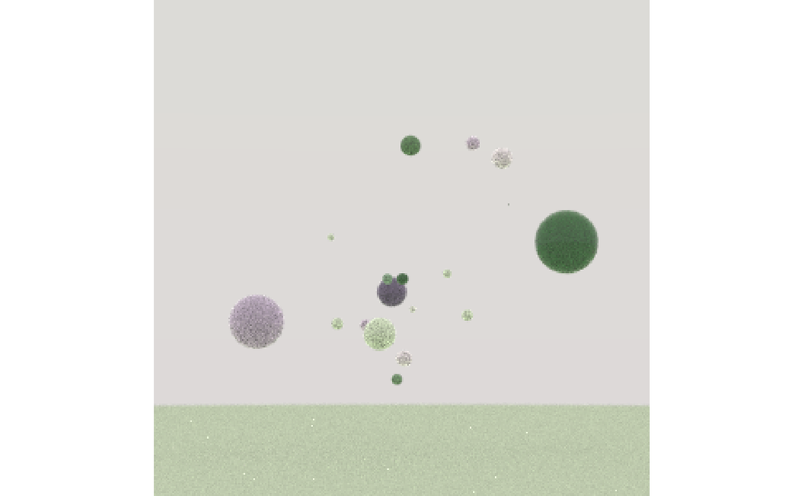

```r
render_scene(#file = glue::glue("corpuscular-{seed}.png"),
             scene,
             parallel = TRUE,
             ambient_light = TRUE,
             width = 300,#1500,
             height = 300,#1500,
             samples = 75 ,#+ abs(rnorm(1, 0, 100)),
             backgroundhigh = col_palette[bkg_c],
             backgroundlow = col_palette[bkg_c - sample.int(4, 1)],
             lookfrom = c(sample(c(-1, 1), 1) * 13,
                          3 + runif(1,
                                    min = -3,
                                    max = 3),
                          sample(c(-1, 1), 1) * 16),
             lookat = c(0, 2, 0))
```

## Cubes with rotation

```r
bkg_c <- sample.int(12, 1) + 3
scene <- generate_ground(material = diffuse(color = col_palette[bkg_c]))
```

```r
obj <- data.frame()

for(i in 1:nrow(df)){
  obj <- rbind(obj,
               cube(x = df$x[i],
                      y = df$y[i],
                      z = df$z[i],
                      width = df$r[i],
                      angle = c(45, 45, 45),
                      material = glossy(color=df$color[i])))
}
```

Add the objects to the scene:

```r
scene <- scene |>
  add_object(objects = obj) |>
   add_object(sphere(x = mean(df$x),
                     y = 40,
                     z = mean(df$z),
                     material=light(intensity=30,
                                    invisible = TRUE)))
```

Render the scene using randomly drawn colors from the chosen palette for the background.

[output not shown]

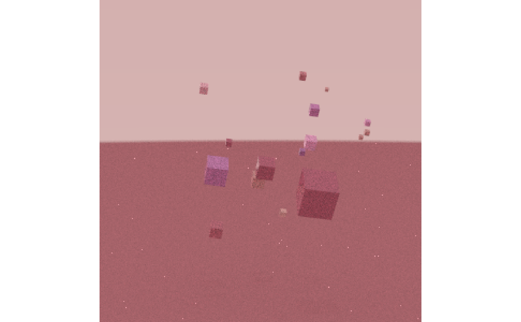

```r
render_scene(#file = glue::glue("corpuscular-{seed}.png"),
             scene,
             parallel = TRUE,
             ambient_light = TRUE,
             width = 300,#1500,
             height = 300,#1500,
             samples = 75 ,#+ abs(rnorm(1, 0, 100)),
             backgroundhigh = col_palette[bkg_c],
             backgroundlow = col_palette[bkg_c - sample.int(4, 1)],
             lookfrom = c(sample(c(-1, 1), 1) * 13,
                          3 + runif(1,
                                    min = -3,
                                    max = 3),
                          sample(c(-1, 1), 1) * 16),
             lookat = c(0, 2, -1))
```